# Predicting Location via Indoor Positioning Systems

Chapter 1, Nolan & Temple Lang

John Ensley

2017-10-14

# Preface

This is a case study from Chapter 1 of **Data Science in R** (Nolan and Temple Lang 2015).

Nolan, Deborah, and Duncan Temple Lang. 2015. *Data Science in R: A Case Studies Approach to Computational Reasoning and Problem Solving*. Chapman & Hall/CRC.

# Introduction

The growth of wireless networking has generated commercial and research interests in statistical methods to reliably track people and things inside stores, hospitals, warehouses, and factories. Global positioning systems (GPS) do not work reliably inside buildings, but with the proliferation of wireless local area networks (LANs), indoor positioning systems (IPS) can utilize WiFi signals detected from network access points to answer questions such as: where is a piece of equipment in a hospital? where am I? and who are my neighbors? Ideally, with minimal training, calibration, and equipment, these questions can be answered well in near real-time.

To build an indoor positioning system requires a reference set of data where the signal strength between a hand-held device such as a cellular phone or laptop and fixed access points (routers) are measured at known locations throughout the building. With these training data, we can build a model for the location of a device as a function of the strength of the signals between the device and each access point. Then we use this model to predict the location of a new unknown device based on the detected signals for the device. In this chapter, we examine nearly one million measurements of signal strength recorded at 6 stationary WiFi access points (routers) within a building at the University of Mannheim and develop a statistical IPS.

Our first step in this process is to understand how the data were collected and formatted. In Section 1.2, we do this by reading documentation provided by the researchers who have recorded the data and by carrying out our own investigations. After we have a sense of the data, we organize them into a structure suitable for analysis. We then clean the data in Section 1.3, and before we begin our modeling, we examine signal strength more closely to better understand its statistical properties (in Section 1.4). Then in Section 1.5 we pursue a nearest neighbor method for predicting location and we test it on a second set of data, also provided by the researchers at Mannheim.

## Computational Topics

- string manipulation
- data structures and representation, including variable length observations
- aggregating data in ragged arrays
- exploratory data analysis and visualization
- modular functions
- debugging
- nearest neighbor methods
- cross-validation for parameter selection

# The Raw Data

Two relevant data sets for developing an IPS are available on the [CRAWDAD site](https://crawdad.org/mannheim/compass/20080411/) (A Community Resource for Archiving Wireless Data At Dartmouth)(King et al. 2008). One is a reference set, termed “offline,” that contains signal strengths measured using a hand-held device on a grid of 166 points spaced 1 meter apart in the hallways of one floor of a building at the University of Mannheim. The floor plan, which measures about 15 meters by 36 meters, is displayed in Figure @ref(fig:floorplan). The grey circles on the plan mark the locations where the offline measurements were taken and the black squares mark 6 access points. These reference locations give us a calibration set of signal strengths for the building, and we use them to build our model to predict the locations of the hand-held device when its position is unknown.

King, Thomas, Stephan Kopf, Thomas Haenselmann, Christian Lubberger, and Wolfgang Effelsberg. 2008. “CRAWDAD Dataset Mannheim/Compass (V. 2008-04-11).” Downloaded from https://crawdad.org/mannheim/compass/20080411.

(#fig:floorplan)Floor plan of the test environment. In this floor plan, the 6 fixed access points are denoted by black square markers, the offline/training data were collected at the locations marked by grey dots, and the online measurements were recorded at randomly selected points indicated with black dots. The grey dots are spaced one meter apart.

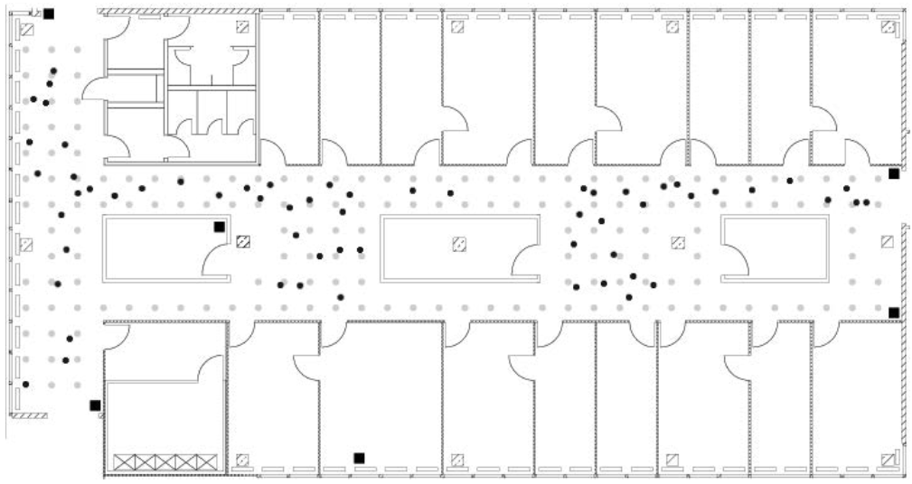

In addition to the $(x,y)$ coordinates of the hand-held device, the orientation of the device was also provided. Signal strengths were recorded at 8 orientations in 45 degree increments (i.e., 0, 45, 90, and so on). Further, the documentation for the data indicates that 110 signal strength measurements were recorded to each of the 6 access points for every location-orientation combination.

In addition to the offline data, a second set of recordings, called the “online” data, is available for testing models for predicting location. In these data, 60 locations and orientations are chosen at random and 110 signals are measured from them to each access point. The test locations are marked by black dots in Figure @ref(fig:floorplan). In both the offline and online data some of these 110 signal strength values were not recorded. Additionally, measurements from other hand-held devices, e.g., phone or laptop, in the vicinity of the experimental unit appear in some offline records.

The documentation for the data (King et al. 2008) describes the format of the data file. Additionally, we can examine the files ourselves with a plain text editor, and we find that each of the two files (offline and online) have the same basic format and start with something similar to

King, Thomas, Stephan Kopf, Thomas Haenselmann, Christian Lubberger, and Wolfgang Effelsberg. 2008. “CRAWDAD Dataset Mannheim/Compass (V. 2008-04-11).” Downloaded from https://crawdad.org/mannheim/compass/20080411.

```
# timestamp=2006-02-11 08:31:58
# usec=250
# minReadings=110
t=1139643118358;id=00:02:2D:21:0F:33;pos=0.0,0.0,0.0;degree=0.0;00:14:bf:b1:97:8a=-38,2437000000,3;00:14:bf:b1:97:90=-56,2427000000,3;00:0f:a3:39:e1:c0=-53,2462000000,3;00:14:bf:b1:97:8d=-65,2442000000,3;00:14:bf:b1:97:81=-65,2422000000,3;00:14:bf:3b:c7:c6=-66,2432000000,3;00:0f:a3:39:dd:cd=-75,2412000000,3;00:0f:a3:39:e0:4b=-78,2462000000,3;00:0f:a3:39:e2:10=-87,2437000000,3;02:64:fb:68:52:e6=-88,2447000000,1;02:00:42:55:31:00=-84,2457000000,1
```

The available documentation indicates that the format of the data is:

```
t="Timestamp";
id="MACofScanDevice";
pos="RealPosition";
degree="orientation";
MACofResponse1="SignalStrengthValue,Frequency,Mode"; ...
MACofResponseN="SignalStrengthValue,Frequency,Mode"
```

where the units of measurement are shown in Table @ref(tab:units). The MAC (media access control) variable refers to the MAC address of a hardware device, which is a unique identifier that allows a network card for a computer, access point, or other piece of equipment to be identified on a network. By convention, this identifier is written in the form `mm:mm:mm:ss:ss:ss` where `mm` and `ss` are 2 hexadecimal digits (0, 1, …, 9, a, b, c, d, e, f). The first of these 3 sets of pairs of digits, i.e., `mm:mm:mm`, identifies the manufacturer of the equipment. The second set of 3 pairs (the `ss`) identifies the particular piece of equipment, both the model and the unique device. The `MACofResponse1 ... MACofResponseN` in these data indicate that one line consists of a variable number of MAC address measurements. That is, these records are not of equal length, but form ragged arrays that depend on the number of signals detected. For example, consider another line (the 2,000th) in the input file:

```
t=1139644637174;id=00:02:2D:21:0F:33;pos=2.0,0.0,0.0;degree=45.5;00:14:bf:b1:97:8a=-33,2437000000,3;00:14:bf:b1:97:8a=-38,2437000000,3;00:0f:a3:39:e1:c0=-54,2462000000,3;00:14:bf:b1:97:90=-59,2427000000,3;00:14:bf:b1:97:8d=-70,2442000000,3;00:0f:a3:39:e2:10=-88,2437000000,3;00:0f:a3:39:dd:cd=-67,2412000000,3;02:00:42:55:31:00=-84,2457000000,1
```

We notice several things: this record has 8 readings; the MAC addresses appear in a different order than in the first record; there are 2 readings from the same access point (the 8a access point); and one of the 8 addresses belongs to an `adhoc` device because, according to Table @ref(tab:units), the mode digit indicates whether the recording is for an `adhoc` device (1) or access point (3). If we look at the first observation again, we notice that there are more than 6 MAC addresses with a mode of 3. The “extras” are from other floors in the building.

(#tab:units)Units of Measurement. This table provides the units of measurement for the variables in the offline and online data.

| Variable | Units |
| --- | --- |
| t | timestamp in milliseconds since midnight, January 1, 1970 UTC |
| id | MAC address of the scanning device |
| pos | the physical coordinate of the scanning device |
| degree | orientation of the user carrying the scanning device in degrees |
| MAC | MAC address of a responding peer (e.g., an access point or a device in adhoc mode) with the corresponding values for signal strength in dBm (Decibel-milliwatts), the channel frequency and its mode (ac… |

Now that we have a sense of the format of the input file, we can determine how to read the data into a structure that is conducive to analysis. Let’s think about how we want to ultimately represent the resulting data in R. There are two reasonably obvious choices. The first is to have a row in a data frame for each row in the input file. In this case, the variables are time, mac-id, $x$, $y$, $z$ (for the hand-held device’s location), orientation, and then 4 variables for each of the MAC addresses for which we have a signal. These 4 variables are signal, channel, and type of device, as well as the MAC address. Since the raw observations have a different number of recorded signals, our data frame needs enough columns to accommodate the largest number of recordings.

A second approach is to have the same initial variables describing the hand-held device, i.e., time, MAC address, location, and orientation. After this, we have just 4 other variables: the MAC address of the device from which we received a signal, the signal, the channel, and the type of device. In this scenario, we have a row in our data frame for each signal received. That is, each line in the input file turns into multiple rows in the data frame, corresponding to the number of ‘;’-separated MAC addresses in that line. For example, the first record in the input file becomes 11 rows and the 2000th observation becomes 8 rows in the data frame.

The first approach yields a natural representation that more directly corresponds to the format of the input file. It also avoids repeating the time and location information and so seems more memory efficient. One of the difficulties it presents, however, is that we have to determine how many columns we need, or more specifically, how many MAC addresses received the signal from the device. Even if we drop the `adhoc` readings, we still have to contend with a different ordering of recordings and multiple measurements from the same MAC address. We most likely need two passes of the data to create our data frame: one to determine the unique MAC addresses and the second to organize the data. While we avoid repeating some information, e.g., timestamp, we need to use `NA` values for the observations that do not have recorded signals from all of the MAC addresses. If there are many of these, then the second approach may actually be more memory efficient. The second approach also appears simpler to create.

With the second approach, we can avoid two passes of the data and read the file into a data frame in just one pass. And, this data structure allows us to use group-by operations on the MAC addresses. For now, we adopt the second approach. Later in our work, we create a data frame with the first format. For this, we do not need to return to the original file, but create the alternative data frame from the existing one.

Another consideration in determining how to read the data into R is whether or not the “comment” lines occur only at the beginning/top of the file. We can search in the file for lines that start with a ‘#’ character. To do this, we read the entire document into R using `readLines()` with

```r
txt <- readLines('offline.final.trace.txt')
```

Each line in the offline file has been read into R as a string in the character vector `txt`. We use the `stringr::str_detect()` function to locate lines/strings that begin with a ‘#’ character and tally them with

```r
sum(str_detect(txt, '^#'))
```

```
## [1] 5312
```

Additionally, we use `length()` as follows:

```r
length(txt)
```

```
## [1] 151392
```

to determine that there are 151,392 lines in the offline file. According to the documentation we expect there to be 146,080 lines in the file (166 locations × 8 angles × 110 recordings). The difference between these two (151,392 and 146,080) is 5,312, exactly the number of comments lines.

Generally a good rule of thumb to follow is to check our assumptions about the format of a file and not just look at the first few lines.

## Processing the Raw Data

Now that we have determined the desired target representation of the data in R, we can write the code to extract the data from the input file and manipulate it into that form. The data are not in a rectangular form so we cannot simply use a function such as `read.table()`. However, there is structure in the observations that we can use to process the lines of text. For example, the main data elements are separated by semicolons. Let’s see how the semicolon splits the fourth line, i.e., the first line that is not a comment:

```r
str_split(txt[4], ';', simplify = TRUE) %>% drop()
```

```
##  [1] "t=1139643118358"
##  [2] "id=00:02:2D:21:0F:33"
##  [3] "pos=0.0,0.0,0.0"
##  [4] "degree=0.0"
##  [5] "00:14:bf:b1:97:8a=-38,2437000000,3"
##  [6] "00:14:bf:b1:97:90=-56,2427000000,3"
##  [7] "00:0f:a3:39:e1:c0=-53,2462000000,3"
##  [8] "00:14:bf:b1:97:8d=-65,2442000000,3"
##  [9] "00:14:bf:b1:97:81=-65,2422000000,3"
## [10] "00:14:bf:3b:c7:c6=-66,2432000000,3"
## [11] "00:0f:a3:39:dd:cd=-75,2412000000,3"
## [12] "00:0f:a3:39:e0:4b=-78,2462000000,3"
## [13] "00:0f:a3:39:e2:10=-87,2437000000,3"
## [14] "02:64:fb:68:52:e6=-88,2447000000,1"
## [15] "02:00:42:55:31:00=-84,2457000000,1"
```

Within each of these shorter strings, the “name” of the variable is separated by an ‘=’ character from the associated value. In some cases this value contains multiple values where the separator is a ‘,’. For example, “pos=0.0,0.0,0.0” consists of 3 position variables that are not named. We can take this vector, which we created by splitting on the semi-colon, and further split each element at the ‘=’ characters. Then we can process the resulting strings by splitting them at the ‘,’ characters. We can use

```
tokens <- stringr::str_split(txt[4], '[;=,]')
```

to split at a ‘;’, ‘=’, or ‘,’ character. The following function takes one line and creates a data frame of all of the signals from that particular device.

```r
process_line <- function(x) {
  tokens <- str_split(x, '[;=,]', simplify = TRUE) %>% drop()
  if (length(tokens) <= 10) return(NULL)
  mac_signals <- matrix(tokens[-(1:10)],
                        ncol = 4,
                        byrow = TRUE)
  device_info <- matrix(tokens[c(2, 4, 6:8, 10)],
                        nrow = nrow(mac_signals),
                        ncol = 6,
                        byrow = TRUE)
  df <- as_data_frame(cbind(device_info, mac_signals))
  names(df) <- c('time', 'scan_mac', 'posX', 'posY', 'posZ',
                 'orientation', 'mac', 'signal', 'channel', 'type')
  df
}
```

Next we’ll use `purrr::map_dfr()` to apply this function to every line of the input file and concatenate the results row-wise into a data frame. To make sure everything is working, let’s try it on the first few lines.

```r
tmp <- map_dfr(txt[4:20], process_line)
dim(tmp)
```

```
## [1] 170  10
```

Now we can try it on the entire dataset. We discard the lines starting with the comment character ‘#’ and then pass each remaining line to `process_line()`.

```r
lines <- txt[!str_detect(txt, '^#')]
offline <- map_dfr(lines, process_line)
dim(offline)
```

```
## [1] 1181628      10
```

Our data frame consists of character-valued variables. A next step is to convert these values into appropriate data types, e.g., convert signal strength to numeric, and to further clean the data as needed. This is the topic of the next chapter.

# Cleaning the Data and Building a Representation for Analysis

We convert the position, signal, and time variables to numeric with

```r
num_vars <- c('time', 'posX', 'posY', 'posZ', 'orientation', 'signal')
offline <- offline %>% mutate_at(num_vars, as.numeric)
```

In our analysis, we plan to use only the signal strengths measured to the fixed access points to develop and test our model, so we will drop all records for `adhoc` measurements and remove the `type` variable from our data frame.

```r
offline <- offline %>%
  filter(type == 3) %>%
  select(-type)
dim(offline)
```

```
## [1] 978443      9
```

We have removed about 200,000 records from our data frame.

Next we consider the time variable. According to the documentation, time is measured in the number of milliseconds from midnight on January 1st, 1970. This is the origin used for the `POSIXt` format, but with `POSIXt`, it is the number of seconds, not milliseconds. We can scale the value of time to seconds and then simply set the class of the `time` element in order to have the values appear and operate as date-times in R. We keep the more precise time in `rawtime` just in case we need it. We perform the conversion as follows:

```r
offline <- offline %>%
  mutate(rawtime = time,
         time = lubridate::as_datetime(time / 1000))
```

Now that we have completed these conversions, we check the types of the variables in the data frame with

```r
unlist(sapply(offline, class))
```

```
##       time1       time2    scan_mac        posX        posY        posZ
##   "POSIXct"    "POSIXt" "character"   "numeric"   "numeric"   "numeric"
## orientation         mac      signal     channel     rawtime
##   "numeric" "character"   "numeric" "character"   "numeric"
```

We have the correct shape for the data and even the correct types. We next verify that the actual values of the data look reasonable. There are many approaches we can take to do this. We start by looking at a summary of each numeric variable with

```r
offline %>% select(num_vars) %>% summary()
```

```
##       time                          posX            posY
##  Min.   :2006-02-11 07:31:58   Min.   : 0.00   Min.   : 0.000
##  1st Qu.:2006-02-11 13:21:27   1st Qu.: 2.00   1st Qu.: 3.000
##  Median :2006-02-11 19:57:58   Median :12.00   Median : 6.000
##  Mean   :2006-02-16 14:57:37   Mean   :13.52   Mean   : 5.897
##  3rd Qu.:2006-02-19 14:52:40   3rd Qu.:23.00   3rd Qu.: 8.000
##  Max.   :2006-03-09 20:41:10   Max.   :33.00   Max.   :13.000
##       posZ    orientation        signal
##  Min.   :0   Min.   :  0.0   Min.   :-99.0
##  1st Qu.:0   1st Qu.: 90.0   1st Qu.:-69.0
##  Median :0   Median :180.0   Median :-60.0
##  Mean   :0   Mean   :167.2   Mean   :-61.7
##  3rd Qu.:0   3rd Qu.:270.0   3rd Qu.:-53.0
##  Max.   :0   Max.   :359.9   Max.   :-25.0
```

We also convert the character variables to factors and examine them with

```r
offline %>%
  select(mac, channel, scan_mac) %>%
  mutate_all(as_factor) %>%
  summary()
```

```
##                 mac               channel                    scan_mac
##  00:0f:a3:39:e1:c0:145862   2462000000:189774   00:02:2D:21:0F:33:978443
##  00:0f:a3:39:dd:cd:145619   2437000000:152124
##  00:14:bf:b1:97:8a:132962   2412000000:145619
##  00:14:bf:3b:c7:c6:126529   2432000000:126529
##  00:14:bf:b1:97:90:122315   2427000000:122315
##  00:14:bf:b1:97:8d:121325   2442000000:121325
##  (Other)          :183831   (Other)   :120757
```

After examining these summaries, we find a couple of anomalies:

- There is only one value for `scan_mac`, the MAC address for the hand-held device from which the measurements were taken. We might as well discard this variable from our data frame. However, we may want to note this value to compare it with the online data.
- All of the values for `posZ`, the elevation of the hand-held device, are 0. This is because all of the measurements were taken on one floor of the building. We can eliminate this variable also.

We modify our data frame accordingly,

```r
offline <- offline %>% select(-posZ, -scan_mac)
```

## Exploring Orientation

According to the documentation, we should have only 8 values for orientation, i.e., 0, 45, 90, …, 315. We can check this with

```r
length(unique(offline$orientation))
```

```
## [1] 203
```

Clearly, this is not the case. Let’s examine the distribution of orientation:

(#fig:ecdf)Empirical CDF of Orientation for the Hand-Held Device. This empirical distribution function of orientation shows that there are 8 basic orientations that are 45 degrees apart. We see from the steps in the function that these orientations are not exactly 45, 90, 135, etc. Also, the 0 orientation is split into the two groups, one near 0 and the other near 360.

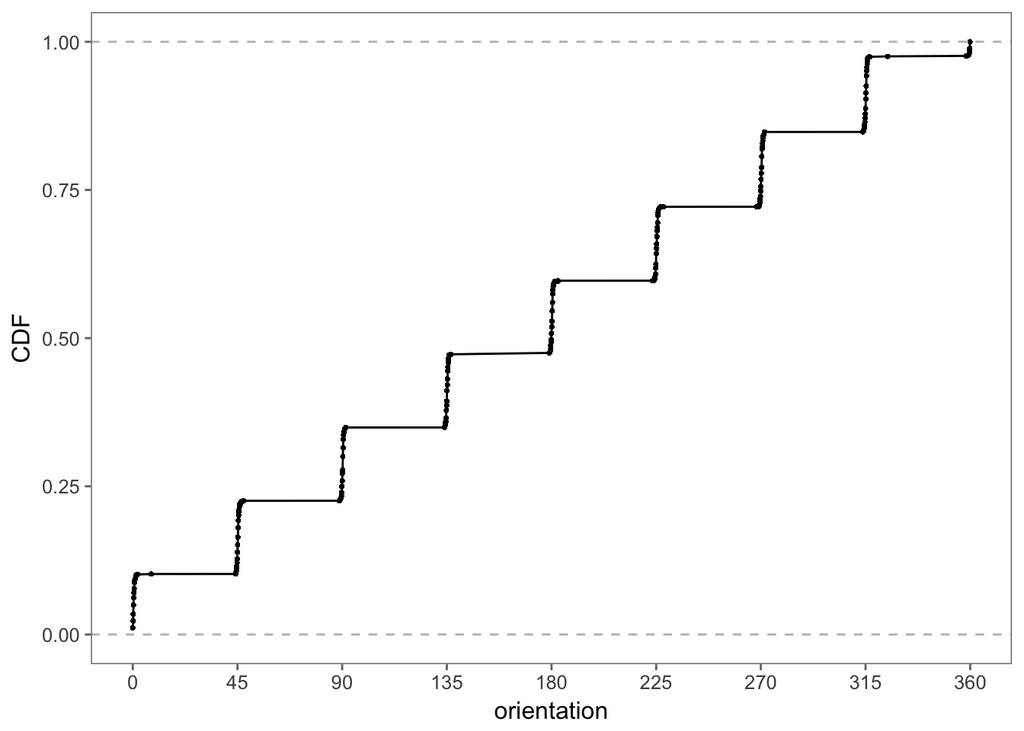

```r
e <- ecdf(offline$orientation)
data_frame(orientation = offline$orientation,
           CDF = e(orientation)) %>%
  ggplot(aes(orientation, CDF)) +
  geom_point(size = 0.4) +
  geom_line() +
  geom_hline(yintercept = 0:1, color = 'grey', linetype = 'dashed') +
  scale_x_continuous(breaks = seq(0, 360, by = 45))
```

An annotated version of this plot appears in Figure @ref(fig:ecdf). It shows the orientation values are distributed in clusters around the expected angles. Note the values near 0 and near 360 refer to the same direction. That is, an orientation value 1 degree before 0 is reported as 359 and 1 degree past 0 is a 1.

Although the experiment was designed to measure signal strength at 8 orientations – 45 degree intervals from 0 to 315 – these orientations are not exact. However, it may be useful in our analysis to work with values corresponding to the 8 equi-spaced angles. That is, we want to map 47.5 to 45, and 358.2 to 0, and so on. To do this, we take each value and find out to which of the 8 orientations it is closest and we return that orientation. We must handle values such as 358.2 carefully as we want to map them to 0, not to the closer 315. The following makes this conversion:

```r
round_orientation = function(angles) {
  refs = seq(0, by = 45, length  = 9)
  q = sapply(angles, function(o) which.min(abs(o - refs)))
  c(refs[1:8], 0)[q]
}
```

```r
offline <- offline %>%
  mutate(angle = cut(offline$orientation,
                     breaks = seq(0, 405, by = 45) - 45/2,
                     labels = seq(0, 360, by = 45))) %>%
  mutate(angle = factor(c(seq(0, 315, by = 45), 0)[as.numeric(angle)]))
```

We check that the results are as we expect with boxplots:

(#fig:orientation)Boxplots of Orientation for the Hand-Held Device. These boxplots of the original orientation against the rounded value confirm that the values have mapped correctly to 0, 45, 90, 135, etc. The “outliers” at the top left corner of the plot are the values near 360 that have been mapped to 0.

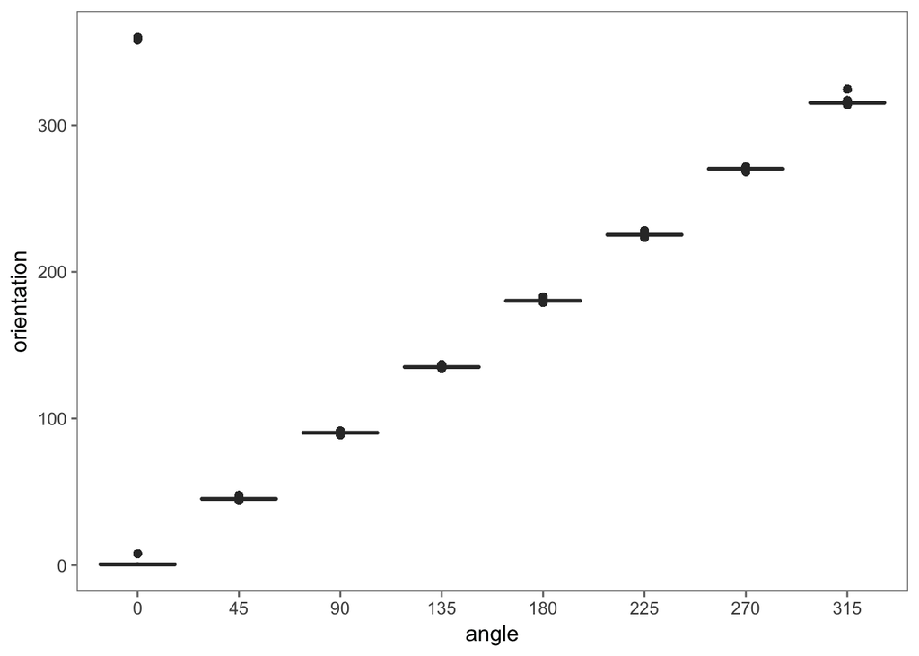

```r
ggplot(offline, aes(angle, orientation)) +
  geom_boxplot()
```

From Figure @ref(fig:orientation) we see that the new values look correct and the original values near 360 degrees are mapped to 0. It also shows the variability in the act of measuring.

## Exploring MAC Addresses

From the `summary()` information, it seems that there may be a one-to-one mapping between the MAC address of the access points and channel. For example, the summary statistics show there are 126,529 occurrences of the address `00:14:bf:3b:c7:c6` and the same number of occurrences of channel `2432000000`. To help us ascertain if we do have a one-to-one mapping, we look at the relationship between the MAC address and channel.

How many unique addresses and channels do we have? There should be the same number, if there is a one-to-one mapping. We find:

```r
c(length(unique(offline$mac)), length(unique(offline$channel)))
```

```
## [1] 12  8
```

There are 12 MAC addresses and 8 channels. We were given the impression from the building plan (see Figure @ref(fig:floorplan)) that there are only 6 access points. Why are there 8 channels and 12 MAC addresses? Rereading the documentation we find that there are additional access points that are not part of the testing area and so not seen on the floor plan. Let’s check the counts of observations for the various MAC addresses with `table()`:

```r
table(offline$mac)
```

```
##
## 00:04:0e:5c:23:fc 00:0f:a3:39:dd:cd 00:0f:a3:39:e0:4b 00:0f:a3:39:e1:c0
##               418            145619             43508            145862
## 00:0f:a3:39:e2:10 00:14:bf:3b:c7:c6 00:14:bf:b1:97:81 00:14:bf:b1:97:8a
##             19162            126529            120339            132962
## 00:14:bf:b1:97:8d 00:14:bf:b1:97:90 00:30:bd:f8:7f:c5 00:e0:63:82:8b:a9
##            121325            122315               301               103
```

Clearly the first and the last two MAC addresses are not near the testing area or were only working/active for a short time during the measurement process because their counts are very low. It’s probably also the case that the third and fifth addresses are not among the access points displayed on the map because they have much lower counts than the others and these are far lower than the possible 146,080 recordings (recall that there are potentially signals recorded at 166 grid points, 8 orientations, and 110 replications).

(#fig:coffer)Screenshot of the coffer.com Mac Address Lookup Form. The coffer.com website offers lookup services to find the MAC address for a vendor and vice versa.

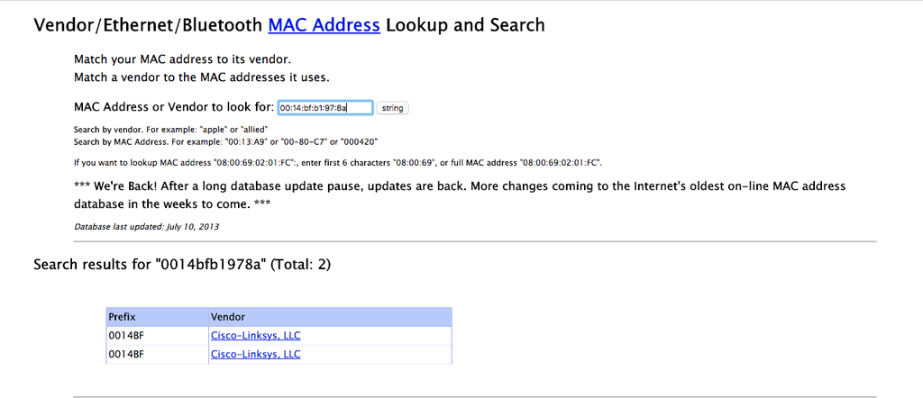

According to the documentation, the access points consist of 5 Linksys/Cisco and one Lancom L-54g routers. We look up these MAC addresses at the http://coffer.com/mac_find/ site to find the vendor addresses that begin with `00:14:bf` belong to Linksys devices, those beginning with `00:0f:a3` belong to Alpha Networks, and Lancom devices start with `00:a0:57` (see Figure @ref(fig:coffer)). We do have 5 devices with an address that begins `00:14:bf`, which matches with the Linksys count from the documentation. However, none of our MAC addresses begin with `00:a0:57` so there is a discrepancy with the documentation. Nonetheless, we have discovered valuable information for piecing together a better understanding of the data. For now, let’s keep the records from the top 7 devices. We do this with

```r
top_macs <- offline %>%
  count(mac) %>%
  top_n(7, n) %>%
  arrange(desc(n)) %>%
  .$mac
offline <- offline %>% filter(mac %in% top_macs)
```

Finally, we create a table of counts for the remaining MAC×channel combinations and confirm there is one non-zero entry in each row.

```r
mac_channel <- table(offline$mac, offline$channel)
apply(mac_channel, 1, function(x) sum(x > 0))
```

```
## 00:0f:a3:39:dd:cd 00:0f:a3:39:e1:c0 00:14:bf:3b:c7:c6 00:14:bf:b1:97:81
##                 1                 1                 1                 1
## 00:14:bf:b1:97:8a 00:14:bf:b1:97:8d 00:14:bf:b1:97:90
##                 1                 1                 1
```

Indeed we see that there is a one-to-one correspondence between MAC address and channel for these 7 devices. This means we can eliminate `channel` from `offline`, i.e.,

```r
offline <- offline %>% select(-channel)
```

## Exploring the Position of the Hand-Held Device

Lastly, we consider the position variables, `posX` and `posY`. For how many different locations do we have data?

```r
loc_counts <- offline %>%
  group_by(posX, posY) %>%
  tally()
```

We have 166 different locations with roughly 5,500 recordings at each position. This is in accord with 8 orientations × 110 replications × 7 access points, which is 6,160 signal strength measurements.

We can visualize all 166 counts by adding tiles at each location and coloring them according to the counts. We see in Figure @ref(fig:loc-counts) that there are roughly the same number of signals detected at each location.

(#fig:loc-counts)Counts of signals detected at each position. Plotted at each location in the building is the total number of signals detected from all access points for the offline data. Ideally for each location, 110 signals were measured at 8 angles for each of 6 access points, for a total of 5280 recordings. These data include a seventh Mac address and not all signals were detected, so there are about 5500 recordings at each location.

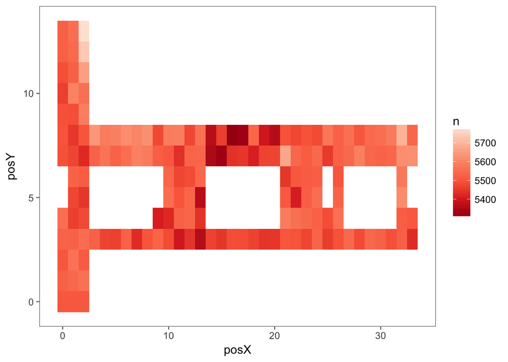

```r
ggplot(loc_counts, aes(posX, posY, fill = n)) +
  geom_tile() +
  scale_fill_distiller(palette = 'Reds')
```

## Creating a Function to Prepare the Data

We have examined all the variables except `time` and `signal`. This process has helped us clean our data and reduce it to those records that are relevant to our analysis. We leave the examination of the signals to the next section where we study its distributional properties. As for `time`, while this variable is not directly related to our model, it indicates the order in which the observations were taken. In an experiment, this can be helpful in uncovering potential sources of bias. For example, the person carrying the hand-held device may have changed how the device was carried as the experiment progressed and this change may lead to a change in the strength of the signal. Plots and analyses of the relationship between time and other variables can help us uncover such potential problems. We leave this investigation as an exercise.

Since we also want to read the online data in R, we turn all of these commands into a function called `read_data()`. Additionally, if we later change our mind as to how we want to handle some of these special cases, e.g., to keep `channel` or `posZ`, then we can make a simple update to our function and rerun it. We might even add a parameter to the function definition to allow us to process the data in different ways. We leave it as an exercise to create `read_data()`.

```r
read_data <- function(file, subMacs) {
  txt <- readLines(file)
  lines <- txt[!str_detect(txt, '^#')]
  rawdata <- map_dfr(lines, process_line)
  # clean the raw data
  num_vars <- c('time', 'posX', 'posY', 'posZ', 'orientation', 'signal')
  rawdata <- rawdata %>%
    mutate_at(num_vars, as.numeric) %>%
    filter(type == '3') %>%
    select(-type) %>%
    mutate(rawtime = time,
           time = lubridate::as_datetime(time / 1000)) %>%
    select(-posZ, -scan_mac)
  rawdata <- rawdata %>%
    mutate(angle = cut(rawdata$orientation,
                       breaks = seq(0, 405, by = 45) - 45/2,
                       labels = seq(0, 360, by = 45))) %>%
    mutate(angle = factor(c(seq(0, 315, by = 45), 0)[as.numeric(angle)])) %>%
    filter(mac %in% subMacs) %>%
    select(-channel)
}
```

We call `read_data()` to create the offline data frame with

```r
offline_redo <- read_data('offline.final.trace.txt', subMacs = unique(offline$mac))
```

Then we use the `identical()` function to check this version of the data frame against the one that we already created:

```r
identical(offline, offline_redo)
```

```
## [1] TRUE
```

This confirms that our function behaves as expected.

# Signal Strength Analysis

We have used visualization and statistical summaries to help clean and format the data, and now we turn to investigating the properties of the response variable, signal strength. We want to learn more about how the signals behave before designing a model for IPS. The following questions guide us in our investigations.

- We have measured the signal strength to an access point multiple times at each location and orientation. How do these signal strengths behave? That is, what is the distribution of the repeated measurements at each location and orientation? Does signal strength behave similarly at all locations? Or do the location, orientation, and access point affect this distribution?
- In a laboratory setting, signal strength decays linearly with log distance and a simple triangulation using the signal strength from 3 access points can accurately pinpoint the location of a device. In practice, physical characteristics of a building and human activity can add significant noise to signal strength measurements. How can we characterize the relationship between the signal strength and the distance from the device to the access point? How does the orientation affect this relationship? Is this relationship the same for all access points?

We consider these questions in the next two chapters.

## Distribution of Signal Strength

We want to compare the distribution of signal strength at different orientations and for different access points, so we need to subdivide our data. We are interested in seeing if these distributions are normal or skewed. We also want to look at their variances.

We consider the impact of orientation on signal strength by fixing a location on the map to see how the signal changes as the experimenter rotates through the 8 angles. We also separately examine the MAC addresses because, for example, at an orientation of 90 degrees the experimenter may be facing toward one access point and away from another.

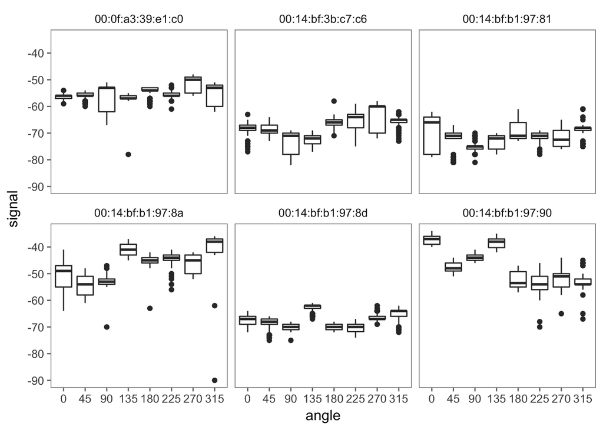

```r
offline %>%
  filter(posX == 2, posY == 12, mac != '00:0f:a3:39:dd:cd') %>%
ggplot(aes(angle, signal)) +
  geom_boxplot() +
  facet_wrap(~ mac)
```

We see in Figure @ref(fig:boxplots-orientation) that the signal strength varies with the orientation for both close and distant access points. Note we have dropped the records for the MAC address of `00:0f:a3:39:dd:cd` because it is identified as the extra address in the next chapter.

Recall from the summary statistics that signal strengths are measured in negative values. That is,

```r
summary(offline$signal)
```

```
##    Min. 1st Qu.  Median    Mean 3rd Qu.    Max.
##  -98.00  -67.00  -59.00  -59.92  -53.00  -25.00
```

The small values, such as -98, correspond to weak signals and the large values, such as -25, are the strong signals.

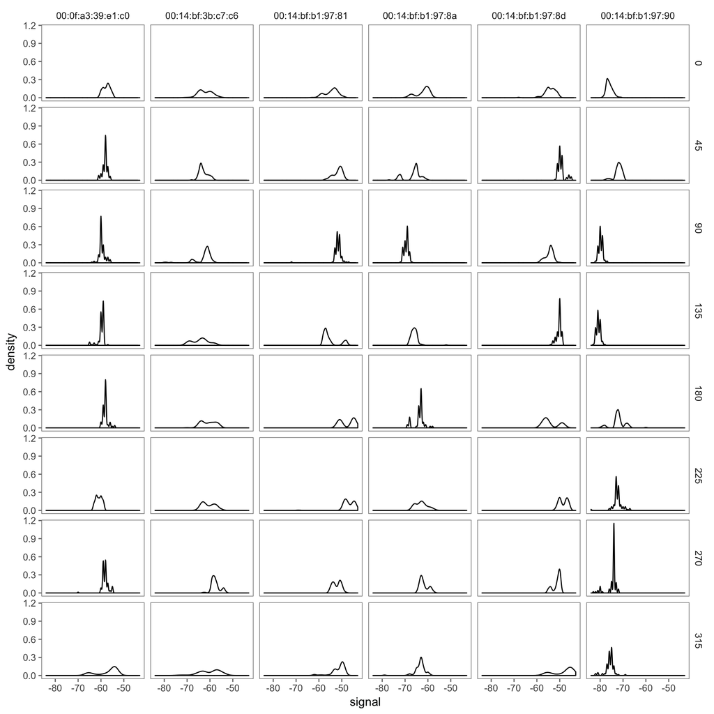

(#fig:density-orientation)Distribution of Signal by Angle for Each Access Point. The density curves shown here are for the signal strengths measured at the position: $x = 24$ and $y = 4$. These 48 density plots represent each of the access point × angle combinations. There are roughly 110 observations in each panel. Some look roughly normal while many others look skewed left.

```r
offline %>%
  filter(posX == 24, posY == 4, mac != '00:0f:a3:39:dd:cd') %>%
  ggplot(aes(signal)) +
  geom_density() +
  facet_grid(factor(angle) ~ mac)
```

Many of these distributions look approximately normal, but there are some serious departures with secondary modes and skewness (see Figure @ref(fig:density-orientation)). Also, the center of the distribution varies with angle and MAC address, which indicates that conditioning on angle and MAC address is warranted.

If we want to examine the distribution of signal strength for all 166 locations, 8 angles, and 6 access points, we need to create thousands of boxplots or density curves. We can, instead, examine summary statistics such as the mean and SD or the median and IQR of signal strength for all location–orientation–access point combinations. For each combination, we have roughly 100 observations.

```r
offline_summary <- offline %>%
  group_by(posX, posY, angle, mac) %>%
  summarise(length = length(signal),
            med = median(signal),
            mean = mean(signal),
            sd = sd(signal),
            iqr = IQR(signal)) %>%
  ungroup()
```

Let’s examine the standard deviations and see if they vary with the average signal strength. We can make boxplots of `sd` for subgroups of `mean` by turning `mean` into a categorical variable. We do this with

(#fig:offline-summary-boxplots)SD of Signal Strength by Mean Signal Strength. The average and SD for the signals detected at each location-angle-access point combination are plotted against each other. The weak signals have low variability and the stronger signals have greater variability.

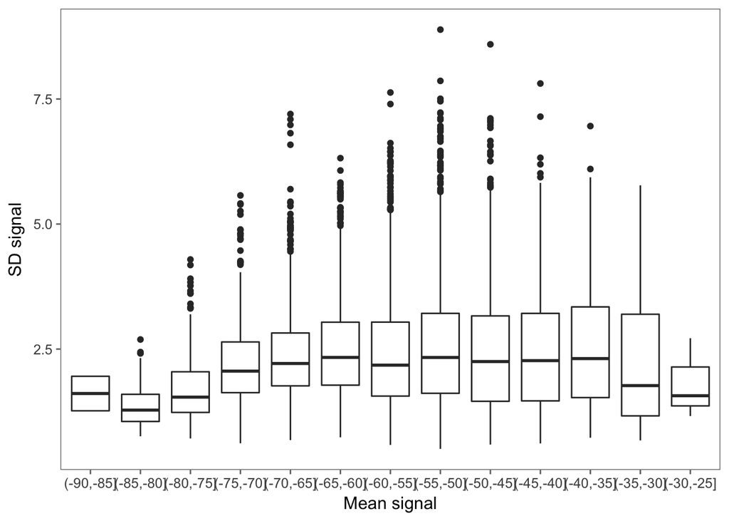

```r
breaks <- seq(-90, -25, by = 5)
offline_summary %>%
  filter(mac != '00:0f:a3:39:dd:cd') %>%
  ggplot(aes(cut(mean, breaks), sd)) +
  geom_boxplot() +
  labs(x = 'Mean signal', y = 'SD signal')
```

We see in Figure @ref(fig:offline-summary-boxplots) that the weakest signals have small standard deviations and that it appears that the SD increases with the average signal strength. If we plan to model the behavior of signal strength, then we want to take these features into consideration.

We examine the skewness of signal strength by plotting the difference, `mean` - `median`, against the number of observations. We do this with a smoother to avoid problems with over-plotting and to see a local average of the difference between the mean and median to better help us assess its size. We do this with:

(#fig:offline-skewness)Comparison of Mean and Median Signal Strength. This smoothed scatter plot shows the difference between the mean and median signal strength for each combination of location, access point, and angle against the number of observations. These differences are close to 0 with a typical deviation of 1 to 2 dBm.

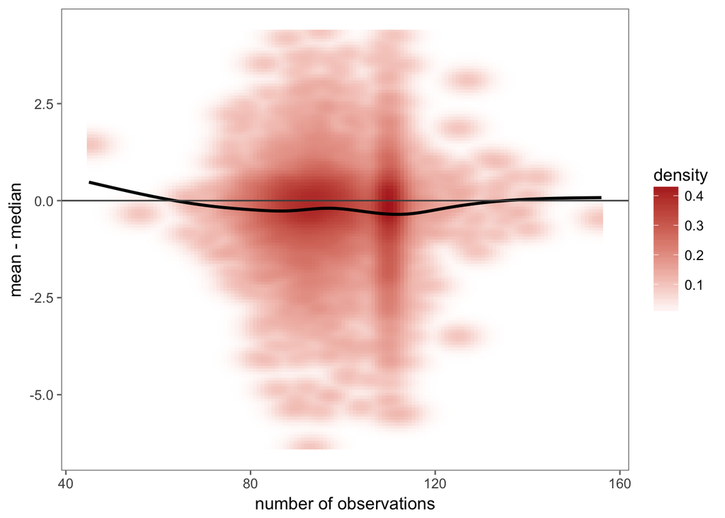

```r
offline_summary %>%
  mutate(diff = mean - med) %>%
ggplot(aes(length, diff)) +
  stat_density2d(aes(fill = ..density..^.25), geom = 'tile', contour = FALSE, n = 140) +
  geom_smooth(color = 'black', se = FALSE) +
  geom_hline(yintercept = 0, size = 0.5, color = 'grey30') +
  scale_fill_continuous(low = 'white', high = 'firebrick', name = 'density') +
  labs(x = 'number of observations', y = 'mean - median')
```

From Figure @ref(fig:offline-skewness) we see that these two measures of centrality are similar to each other; they typically differ by less than 1 to 2 dBm.

## The Relationship between Signal and Distance

One way to examine the relationship between distance and signal strength is to smooth the signal strength over the region where it is measured and create a contour plot, similar to a topographical map; that portion of the floor plan where there is strong signal corresponds to the mountainous regions in the contour map. As with our previous analysis of signal strength, we want to control for the access point and orientation. Let’s begin by selecting one MAC address and one orientation to examine. We choose the summary statistics for an angle×MAC address combination with, e.g.,

```r
one_ap_angle <- offline %>%
  filter(mac == top_macs[5], angle == 0)
```

We can make a topographical map using color, i.e., a heat map. The `fields` package uses the method of thin plate splines to fit a surface to the signal strength values at the observed locations. This package also provides plotting routines for visualizing the surface with a heat map. The `Tps()` function in `fields` requires that we provide a unique “z” value for each $(x, y)$ so we must summarize our signal strengths. Rather than use `offline`, which gives, in `one_ap_angle`, about 100 recordings of signal strength at each location, we subset `offline_summary` with

```r
one_ap_angle <- offline_summary %>%
  filter(mac == top_macs[5], angle == 0)
```

Then, after loading `fields`, we call `Tps()` to fit a smooth surface to mean signal strength:

```r
library(fields)
smooth_ss <- one_ap_angle %>%
  select(posX, posY) %>%
  Tps(one_ap_angle$mean)
```

Next, we use `predictSurface()` to predict the value for the fitted surface at a grid of the observed `posX` and `posY` values, i.e.,

```r
viz_smooth <- predictSurface(smooth_ss)
```

Then we plot the predicted signal strength values using `plot.surface()` as follows:

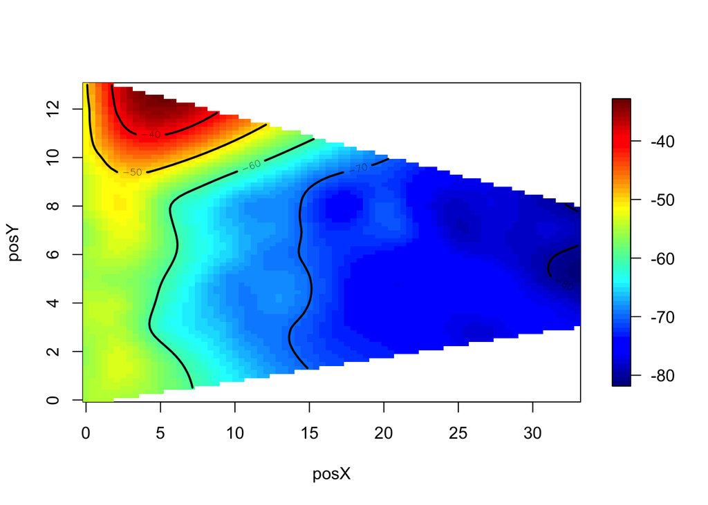

```r
plot.surface(viz_smooth, type = 'C')
```

Lastly, we add the locations where the measurements were taken:

```r
points(one_ap_angle$posX, one_ap_angle$posY, pch = 19, cex = 0.5)
```

We can wrap this plotting routine into its own function so that we can parameterize the MAC address and angle, and if desired, other plotting parameters. Our function, called `surfaceSS()`, has 3 arguments: data for the offline summary data frame, and `mac` and `angle`, which supply the MAC address and angle to select the subset of the data that we want smoothed and plotted.

```r
surfaceSS <- function(df, m, a, ...) {
  library(fields)
  one_ap_angle <- filter(df, .data$mac == m, .data$angle == a)
  viz_smooth <- one_ap_angle %>%
    select(posX, posY) %>%
    Tps(one_ap_angle$mean) %>%
    predictSurface() %>%
    plot.surface(type = 'C', ...)
  points(one_ap_angle$posX, one_ap_angle$posY, pch = 19, cex = 0.5)
  invisible(one_ap_angle)
}
```

We call `surfaceSS()` with a couple of MAC addresses and angles to compare them. To do this, we first modify R’s plotting parameters so that we can place 4 contour plots on one canvas, and we reduce the size allocated to the margins so more of the canvas is dedicated to the heat maps. We save the current settings for the plotting parameters in `par_cur`, and then we make 4 calls to our `surfaceSS()` function using `purrr::pwalk()` as follows:

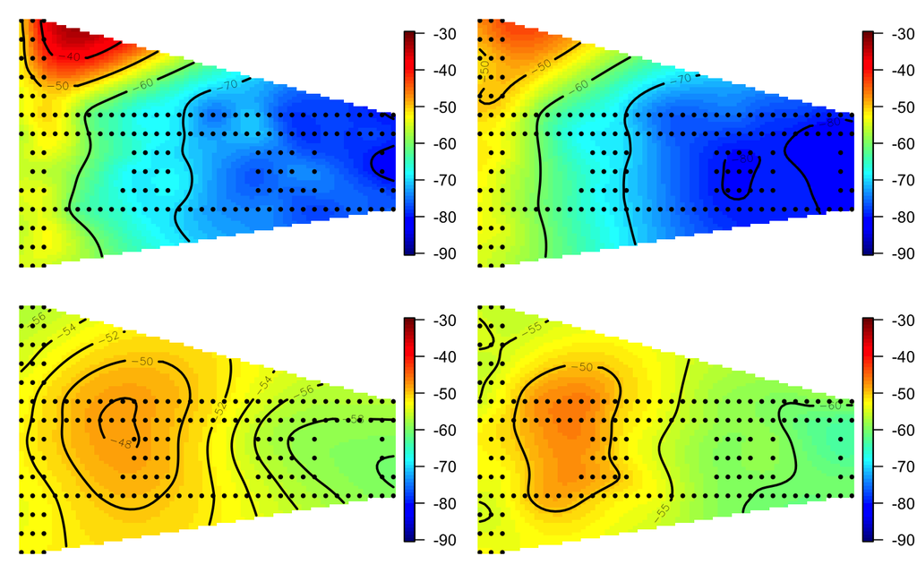

(#fig:mean-signal)Mean Signal at Two Access Points and Two Angles. These four heat maps provide a smooth topographical representation of signal strength. The top two maps are for the access point `00:14:bf:b1:97:90` and the angles 0 (left) and 135 (right). The two bottom heat maps represent the signal strength for the access point `00:0f:a3:39:e1:c0` and the same two angles.

```r
par_cur <- par(mfrow = c(2, 2), mar = rep(1, 4))
args <- data_frame(m = rep(c('00:14:bf:b1:97:90',
                             '00:0f:a3:39:e1:c0'), each = 2),
                   a = rep(c(0, 135), 2))
pwalk(args, surfaceSS, df = offline_summary, zlim = c(-90, -30), axes = FALSE)
```

```r
par(par_cur)
```

In Figure @ref(fig:mean-signal) we see that we can easily identify the location of the access point as the dark red region at the top of the “mountain.” We also confirm the effect of the orientation on signal strength. Additionally, a corridor effect emerges. The signal is stronger relative to distance along the corridors where the signals are not blocked by walls.

We know the locations of the access points based on the floor plan of the building, but we have not been given their exact location and we do not know the mapping between MAC address and access point. Fortunately, the contour maps that we just created make it easy to connect the MAC address to the access point marked on the floor plan in Figure @ref(fig:floorplan). For example, from Figure @ref(fig:mean-signal), the signals appearing in the top row of the plot clearly correspond to the access point in the top left corner of the building. Also, according to the documentation, the training data were measured at 1 meter intervals in the building so we can use the grey dots on the plan to estimate the location of the access points. We find that two MAC addresses have similar heat maps and these both correspond to the access point near the center of the building (i.e., $x = 7.5$ and $y = 6.3$). We choose the first of these and leave as an exercise the analysis of the impact of this decision on predicting location.

```r
offline_summary <- offline_summary %>%
  filter(mac != top_macs[2])
```

We create a small data frame with the relevant positions for the 6 access points on the floor plan with

```r
ap <- data_frame(mac = top_macs[-2],
                 x = c(7.5, 2.5, 12.8, 1, 33.5, 33.5),
                 y = c(6.3, -.8, -2.8, 14, 9.3, 2.8))
ap
```

```
## # A tibble: 6 x 3
##                 mac     x     y
##               <chr> <dbl> <dbl>
## 1 00:0f:a3:39:e1:c0   7.5   6.3
## 2 00:14:bf:b1:97:8a   2.5  -0.8
## 3 00:14:bf:3b:c7:c6  12.8  -2.8
## 4 00:14:bf:b1:97:90   1.0  14.0
## 5 00:14:bf:b1:97:8d  33.5   9.3
## 6 00:14:bf:b1:97:81  33.5   2.8
```

To examine the relationship between signal strength and distance from the access point, we need to compute the distances from the locations of the device emitting the signal to the access point receiving the signal. We first compute the difference between the $x$ coordinate and access point’s $x$ coordinate and the similar difference for the $y$ coordinates. Then we use these differences to find the Euclidean distance between the position of the hand-held device and the access point. We can do all this with

```r
offline_summary <- offline_summary %>%
  left_join(ap, by = 'mac') %>%
  mutate(dist = sqrt((posX - x)^2 + (posY - y)^2)) %>%
  select(-x, -y)
```

Finally, we make a series of scatter plots for each access point and device orientation with

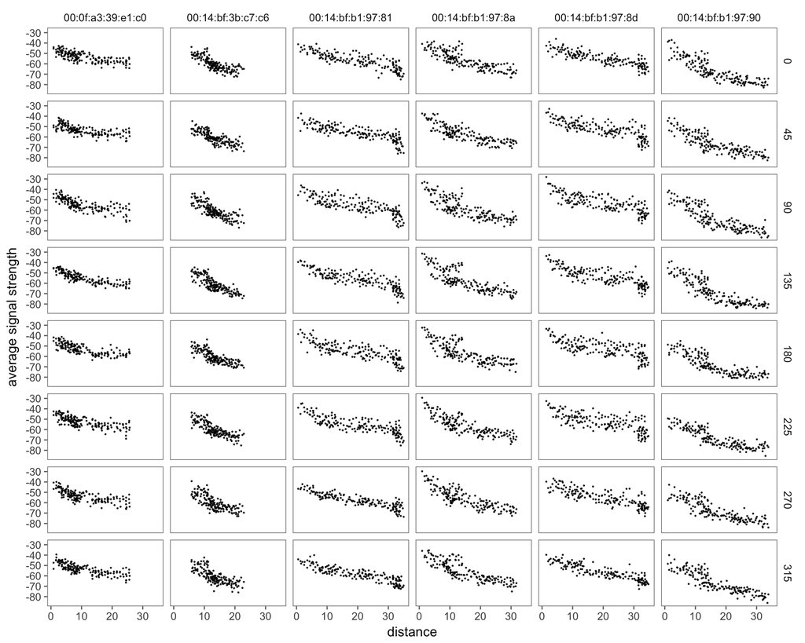

(#fig:signal-distance)Signal Strength vs. Distance to Access Point. These 48 scatter plots show the relationship between the signal strength and the distance to the access point for each of the 6 access points and 8 orientations of the device. The shape is consistent across panels showing curvature in the relationship.

```r
ggplot(offline_summary, aes(dist, mean)) +
  geom_point(size = 0.2, alpha = 0.8) +
  facet_grid(angle ~ mac) +
  labs(x = 'distance', y = 'average signal strength')
```

The scatter plots appear in Figure @ref(fig:signal-distance). There appears to be curvature in the plots. A log transformation might improve the relationship. However, the signals are negative values so we need to be careful in taking a log transformation. We leave it to the reader to further investigate this relationship between signal strength and distance.

# Nearest Neighbor Methods to Predict Location

There are numerous different statistical techniques we can use to estimate the location of a device from the strength of the signal detected between the device and several access points. Here, we use a relatively simple and intuitive approach, called $k$-nearest neighbors or $k$-NN for short. The idea behind the nearest neighbor method (for $k = 1$) is as follows: we have training data where the signal is measured to several access points from known positions throughout a building; when we get a new observation, i.e., a new set of signal strengths for an unknown location, we find the observation in our training data that is closest to this new observation. By close we mean the signals recorded between the access points and the new, unobserved location are close to the signal strengths measured between the access points and an observation in the training data. Then, we simply predict the position of the new observation as the position of that closest training observation. For $k$-nearest neighbors where $k$ is larger than 1, we find the $k$ closest training points (in the signal strength domain) and estimate the new observation’s position by an aggregate of the positions of the $k$ training points.

We naturally think of measuring the distance between two sets of signal strengths with Euclidean distance, i.e.,

$$\sqrt{(S_1^* - S_1)^2 + \cdots + (S_6^* - S_6)^2},$$

where $S_i$ is the signal strength measured between the handheld device and the $i$-th access point for a training observation taken at some specified location, and $S_i^∗$ is the signal measured between the same access point and our new point whose $(x,y)$ values we are trying to predict.

## Preparing the test data

The online data are in `online.final.trace.txt`, and these observations form our test data. We use the `read_data()` function from Chapter @ref(cleandata) to process the raw data with

```r
macs <- unique(offline_summary$mac)
online <- read_data('online.final.trace.txt', subMacs = macs)
```

We have the locations where these test measurements were taken so that we can assess the accuracy of our predictions.

```r
identical(online %>% count(posX, posY, angle) %>% .$n,
          online %>% count(posX, posY) %>% .$n)
```

```
## [1] TRUE
```

This output indicates that signal strengths were recorded at one orientation for each location.

Given that we are computing distances between vectors of 6 signal strengths, it may be helpful to organize the data in a different structure than we have used so far in this chapter. Specifically, rather than a data frame with one column of signal strengths from all access points, let’s organize the data so that we have 6 columns of signal strengths, i.e., one for each of the access points. We summarize the online data into this format, providing the average signal strength at each location as follows:

```r
online_summary <- online %>%
  group_by(posX, posY, angle, mac) %>%
  summarise(avg_ss = mean(signal)) %>%
  spread(mac, avg_ss) %>%
  ungroup()
```

We have kept in the data frame only those variables that we use for making and assessing predictions. This new data frame should have 60 rows and 9 variables, including 6 average signal strengths at the corresponding MAC addresses. We confirm this with:

```r
dim(online_summary)
```

```
## [1] 60  9
```

```r
names(online_summary)
```

```
## [1] "posX"              "posY"              "angle"
## [4] "00:0f:a3:39:e1:c0" "00:14:bf:3b:c7:c6" "00:14:bf:b1:97:81"
## [7] "00:14:bf:b1:97:8a" "00:14:bf:b1:97:8d" "00:14:bf:b1:97:90"
```

To ensure the data is in a consistent format, we extract these steps into a function:

```r
prepare_data <- function(data) {
  data %>%
    group_by(posX, posY, angle, mac) %>%
    summarise(avg_ss = mean(signal)) %>%
    spread(mac, avg_ss) %>%
    ungroup()
}
```

And we use it on both the offline and online data.

```r
offline <- offline %>% filter(mac != top_macs[2])
train <- prepare_data(offline)
test <- prepare_data(online)
```

## Choice of Orientation

In our nearest neighbor model, we want to find records in our offline data, i.e., our training set, that have similar orientations to our new observation because we saw in Chapter @ref(cleandata) that orientation can impact the strength of the signal. To do this, we might consider using all records with an orientation that is within a specified range of the new point’s orientation. Since the observations were recorded in 45 degree increments, we can simply specify the number of neighboring angles to include from the training data. For example, if we want only one orientation then we only include training data with angles that match the rounded orientation value of the new observation. If we want two orientations then we pick those two multiples of 45 degrees that flank the new observation’s orientation; for three, we choose the closest 45 degree increment and one on either side of it, and so on. That is, for `m` the number of angles and `angleNewObs` the angle of the new observation, we find the angles to include from our training data as follows:

```r
new_angle <- 130
m <- 3

refs <- seq(0, by = 45, length = 8)
nearest_angle <- round_orientation(new_angle)
if (m %% 2) {
  angles <- seq(-45 * (m-1)/2, 45 * (m-1)/2, length = m)
} else {
  angles <- seq(-45 * (m/2 - 1), 45 * m/2, length = m)
}
```

Notice that we handle the case of `m` odd and even separately. Also, we must map the angles to values in `refs`, e.g., -45 maps to 315 and 405 maps to 45, so we adjust `angles` with

```r
angles <- (angles + nearest_angle) %% 360
```

After we have the subset of the desired angles, we select the observations from `offline_summary` to analyze with

```r
offline_subset <- offline_summary %>% filter(angle %in% angles)
```

Then we aggregate the signal strengths from these angles and create a data structure that is similar to that of `online_summary`. Rather than repeat the code again, we turn these computations into a helper function, which we call `select_train()`:

```r
select_train <- function(new_angle, data, m) {
  refs <- seq(0, by = 45, length = 8)
  nearest_angle <- round_orientation(new_angle)

  if (m %% 2) {
    angles <- seq(-45 * (m-1)/2, 45 * (m-1)/2, length = m)
  } else {
    angles <- seq(-45 * (m/2 - 1), 45 * m/2, length = m)
  }
  angles <- (angles + nearest_angle) %% 360

  data %>%
    filter(angle %in% angles) %>%
    ungroup()
}
```

We can test our function for an angle of 130 degrees and `m` of 3, i.e., we aggregate the offline data for angles of 90, 135, and 180. We do this with

```r
train130 <- select_train(130, train, m = 3)
```

The results, slightly reformatted for readability, are:

```
## # A tibble: 498 x 9
##     posX  posY  angle `:c0` `:c6` `:81` `:8a` `:8d` `:90`
##    <dbl> <dbl> <fctr> <dbl> <dbl> <dbl> <dbl> <dbl> <dbl>
##  1     0     0     90   -51   -63   -64   -34   -63   -55
##  2     0     0    135   -52   -67   -63   -39   -64   -54
##  3     0     0    180   -55   -68   -62   -34   -66   -56
##  4     0     1     90   -55   -66   -64   -40   -64   -60
##  5     0     1    135   -54   -66   -64   -41   -65   -58
##  6     0     1    180   -50   -64   -63   -37   -68   -59
##  7     0     2     90   -54   -61   -61   -46   -58   -51
##  8     0     2    135   -56   -62   -65   -39   -61   -50
##  9     0     2    180   -54   -60   -61   -48   -61   -57
## 10     0     3     90   -58   -61   -56   -41   -65   -51
## # ... with 488 more rows
```

The `select_train()` function returns a set of $m$×166 signals for each access point.

```r
nrow(train130) / m
```

```
## [1] 166
```

## Finding the Nearest Neighbors

At this point, we have a set of training data that we can use to predict the location of our new point. We want to look at the distance in terms of signal strengths from these training data to the new point. Whether we want the nearest neighbor or the 3 nearest neighbors, we need to calculate the distance from the new point to all observations in the training set. We can do this with the `closest_pts()` function:

```r
closest_pts <- function(train, testvec, k) {
  train %>%
    gather(mac, signal, -(1:2)) %>%
    group_by(posX, posY) %>%
    mutate(diff = signal - testvec) %>%
    summarise(dist = sum(diff*diff)) %>%
    arrange(dist) %>%
    head(k) %>%
    # select(posX, posY) %>%
    ungroup()
}
```

The parameters to this function are the training data and a numeric vector of 6 new signal strengths. Our function returns a data frame containing the locations of the $k$ nearest training observations in order of closeness to the new observation’s signal strength, as well as the value of that distance.

We can use some subset of these ordered locations to estimate the location of the new observation. That is, for some value $k$ of nearest neighbors, we can simply average the first $k$ locations. For example, if `neighbors` contains the $x$ and $y$ values returned from `closest_pts()` (these are the ordered training locations), then we estimate the location of the new observation with the function `avg_neighbors()`.

```r
avg_neighbors <- function(neighbors) {
  neighbors %>% summarise_at(vars(posX:posY), mean)
}
```

Of course, we need not take simple averages. For example, we can use weights in the average that are inversely proportional to the distance (in signal strength) from the test observation. In this case, we also need to return the distance values from the `closest_pts()` function. This alternative approach allows us to include the $k$ points that are close, but to differentiate between them by how close they actually are from the new observation’s signals. The weights might be

$$\frac{1/d_i}{\sum^k_{i=1} 1/d_i},$$

for the $i$-th closest neighboring observation where $d_i$ is the distance from our new point to that nearest reference point (in signal strength space). This might look something like the function `weighted_avg_neighbors()`.

```r
weighted_avg_neighbors <- function(neighbors) {
  neighbors %>%
    mutate(wtdX = posX * (1/dist) / sum(1/dist),
           wtdY = posY * (1/dist) / sum(1/dist)) %>%
    summarise(posX = sum(wtdX), posY = sum(wtdY))
}
```

We may also want to consider different metrics. We have used Euclidean distance, but we may want to try Manhattan distance. We might also be inclined to use medians and not averages when combining neighbors to predict $(x,y)$, if the distribution of the values we are averaging are quite skewed.

We have developed two functions, `train_select()` and `closest_pts()`, to provide the locations in the training data that have signal strengths close to those of a test observation. We can formalize this approach to make predictions for all of our test data. We do this with `my_knn()` as follows:

```r
my_knn <- function(train, test, m = 1, k = 3) {
  pred_xy <- list()
  for (i in 1:nrow(test)) {
    testvec <- test[i, ] %>%
      select(starts_with('00:')) %>%
      unlist()
    train_ss <- select_train(as.numeric(as.character(test$angle[i])), train, m) %>%
      group_by(posX, posY) %>%
      summarise_at(-1, mean)
    neighbors <- closest_pts(train_ss, testvec, k)
    pred_xy[[i]] <- weighted_avg_neighbors(neighbors)
  }
  bind_rows(pred_xy)
}
```

We test our functions with the case of 3 nearest neighbors and 3 orientations with:

```r
est_xy_k3 <- my_knn(train, test, m = 3, k = 3)
```

To assess the fit of the model we can make a map of the actual and predicted locations. Figure @ref(fig:predictions) shows such a map for this model and the 1-NN model. Notice that in general the errors are smaller for 3-NN. Also in the 3-NN model, the large errors seem less problematic as they tend to follow the hallways.

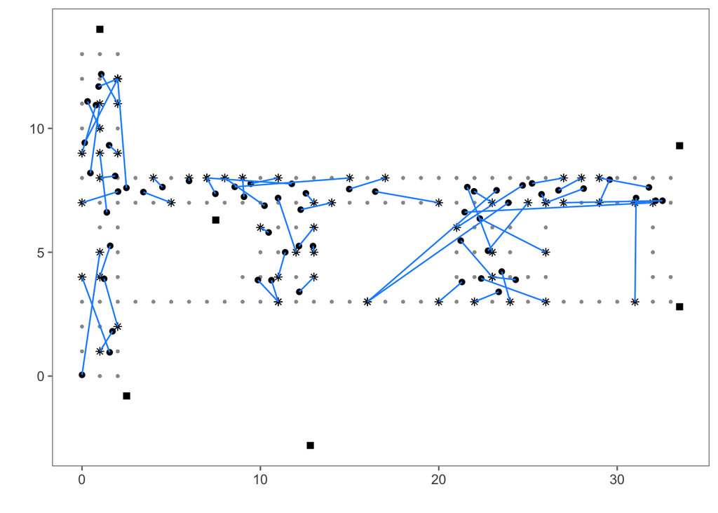

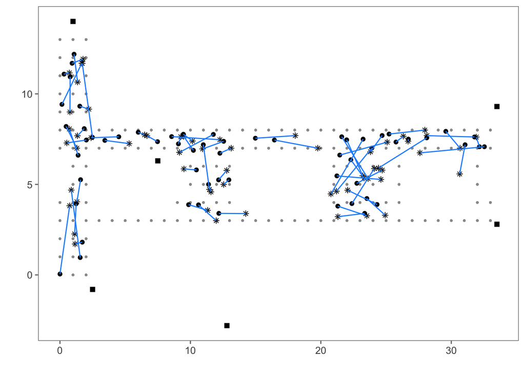

In addition to the visual comparison of the predicted and actual positions, we can compare these fits numerically. For example, we can compute the length of the line segments in each of the figures and sum them to yield a measure of the size of the error. Or, we can find the sum of squared errors with

```r
calc_error <- function(estXY, actualXY) {
  sum(rowSums((estXY - actualXY)^2))
}
```

We apply this function to our two sets of errors to find:

```r
actualXY <- test %>% select(posX, posY)
map_dbl(list(est_xy_k1, est_xy_k3), calc_error, actualXY)
```

[output not shown]

```
## [1] 622.8803 315.9173
```

This confirms what we saw in the figures, that 3 nearest neighbors do a better job of predicting location than one nearest neighbor. The question remains whether some other value of $k$ makes a better predictor.

## Cross-Validation and Choice of $k$

The choice of $k$, the number of neighbors to include in the estimate of a new observation’s position, is a model selection problem. Ideally, we want to choose the value of $k$ independent of our test data so that we do not overfit our model to the training data. The method of $v$-fold cross-validation can help us do this. The idea behind it is quite simple: we divide our training data into $v$ non-overlapping subsets of equal size. Then for each subset, we build models with the data that are not in that subset and we assess the predictive ability of the model using the subset that was left out. We repeat this model fitting and assessment for each of the $v$ folds and aggregate the prediction errors across the folds.

In our nearest neighbor scenario, we use all 8 orientations and 6 MAC addresses with each location. This means that we cross-validate on the 166 locations. Suppose that we take $v = 11$; then each fold has `floor(166/v)`, or 15, locations. We can randomly select these locations with

```r
v <- 11
permute_locs <- train %>%
  select(posX, posY) %>%
  unique() %>%
  nrow() %>%
  sample()
permute_locs <- matrix(permute_locs, ncol = v, nrow = floor(length(permute_locs) / v))
```

```
## Warning in matrix(permute_locs, ncol = v, nrow =
## floor(length(permute_locs)/v)): data length [166] is not a sub-multiple or
## multiple of the number of rows [15]
```

We receive a warning message with the call to `matrix()` because $v$ does not divide evenly into 166, so `permute_locs` does not contain all 166 locations. Each subset of 15 locations is used as the “online” or test data so, e.g., the first online fold is

```r
online_fold <- train[permute_locs[ ,1], ]
```

We need to summarize these data so that the data structure matches that of `online_summary`. This includes selecting an orientation at random because each test observation has only one orientation. (Of course, we could find the nearest neighbors for each of the 8 orientations, but we keep things a bit simpler).

Recall from Section @ref(preparedata) that we summarized the online data into a structure that had 6 columns of signal strength values, one for each access point. It is easier for us to create the test data in its entirety from `offline` and then divide this data structure into its folds. We can use our function `reshape_ss()` to do this. However, there is one important difference – we want to select one angle at random for each location. We can augment `prepare_data()` to conditionally perform this selection, e.g.,

```r
prepare_data <- function(data, sample_angle = FALSE) {
  df <- data %>%
    group_by(posX, posY, angle, mac) %>%
    summarise(avg_ss = mean(signal)) %>%
    spread(mac, avg_ss) %>%
    ungroup()
  if (sample_angle) {
    df <- df %>%
      group_by(posX, posY) %>%
      sample_n(1) %>%
      ungroup()
  }
  df
}
```

After we incorporate this code into `prepare_data()` and augment the function definition to include `sample_angle` with a default value of `FALSE`, then we can summarize and format `offline` with

```r
test_cv <- prepare_data(offline, sample_angle = TRUE)
```

Now, our first fold is:

```r
online_fold <- test_cv[permute_locs[ ,1], ]
```

This structure makes it easier to use our previous code to find the nearest neighbors. Our training data for the first fold is

```r
offline_fold <- train[permute_locs[ ,-1], ]
```

This subset is also in the correct format for our earlier application of the nearest neighbor method. That is, we can use our `my_knn()` function with these cross-validated versions of the online and offline data as follows:

```r
est_fold <- my_knn(offline_fold, online_fold, m = 3, k = 3)
```

Then we find the error in our estimates with

```r
actual_fold <- online_fold %>% select(posX, posY)
calc_error(est_fold, actual_fold)
```

```
## [1] 5278.553
```

For each fold, we want to find the $k$-NN estimates for $k = 1, 2, \dots, K$, for some suitably large $K$. And, we want to aggregate the errors over the $v$ folds. We begin simply by wrapping our code from above in loops over the folds and the number of neighbors. We do this as follows, for $K = 20$:

```r
K <- 20
err <- rep(0, K)

for (j in 1:v) {
  online_fold <- test_cv[permute_locs[ ,j], ]
  offline_fold <- train[permute_locs[ ,-j], ]
  actual_fold <- online_fold %>% select(posX, posY)
  for (k in 1:K) {
    est_fold <- my_knn(offline_fold, online_fold, m = 3, k = k)
    err[k] <- err[k] + calc_error(est_fold, actual_fold)
  }
}
```

(#fig:cverr)Cross Validated Selection of $k$. This line plot shows the sum of square errors as a function of the number of neighbors used in predicting the location of a new observation. The sums of squared errors are obtained via cross-validation of the offline data.

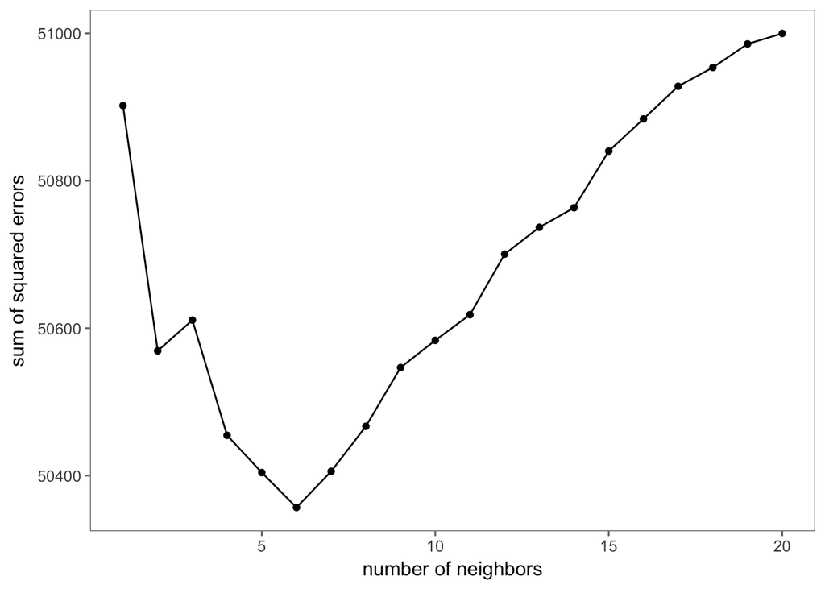

```r
ggplot(data_frame(k = 1:K, err = err), aes(k, err)) +
  geom_point() +
  geom_line() +
  labs(x = 'number of neighbors', y = 'sum of squared errors')
```

```r
est_xy_k6 <- my_knn(train, test, m = 3, k = 6)
```

Then we tally the errors in our predictions with

```r
calc_error(est_xy_k6, actualXY)
```

```
## [1] 261.1878
```

The earlier values for $k = 1$ and $k = 3$ were 622 and 315, respectively. The choice of $k = 6$ may not be the minimizing value for our online data because this value was chosen without reference to the online data. This is the reason we use cross-validation, i.e., we do not use the online data in both the selection of $k$ and the assessment of the predictions.

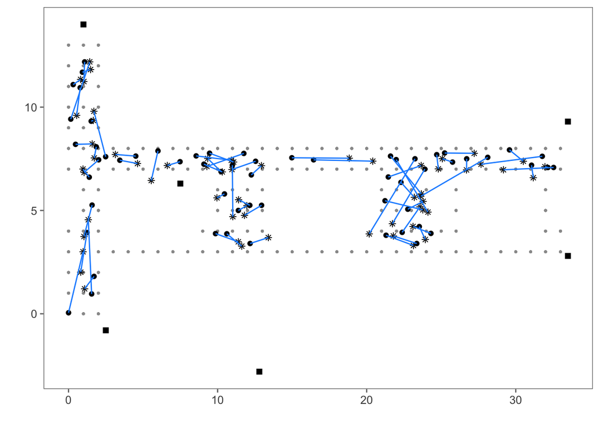

```r
plot_locations(est_xy_k6)
```